# STAT 428: Homework 2: Random Number Generation and Sampling

## Solution 4

**Simulating Beta(2, 4) Random Variables: Which method is better?**

In this exercise, you will simulate Beta(2,4) random variables with target density
$$f(x) \propto x \; (1-x)^{3}.$$
using the Accept/Reject Algorithm with two different instrumental densities.

- **[Method I]** Use uniform RV’s with instrumental density
  $$g_{1}(x) = 1,\quad 0 < x < 1.$$
  - you may use $M \approx 0.1055$.
  - to simulate from $g_{1}$ use the command `x <- runif(1)`.
- **[Method II]** Use the average of two uniform RV’s with instrumental density
  $$g_{2}(x) = 2 - |4x - 2|,\quad 0 < x <1.$$
  - you may use $M \approx 0.2499$.
  - the `R` function for absolute value is `abs`.
  - to simulate from $g_{2}$ use the command `x <- mean(runif(2))`.
- **[Question]** Which method is better? Answer this by responding to the following parts.
- **(a)** Write a program that simulates 10,000 Beta(2,4) random variables using both methods.
- **(b)** Compare the acceptance rates and decide which one is the better algorithm.
- **(c)** Is it correct to use theoretical acceptance rate $\frac{1}{M}$. Why or why not?
- **(c)** Graph histograms of your results.
- **(d)** Summarizes your findings.
- **Hints:**
  - Modify code for simulating Normals from Cauchy that was done in class.
  - It may help to write two separate programs for each method.
- **(a)**

```r
algorithm <- function(n){
  M <- 0.1055
  accept <- 0; num <- 0
  z <- rep(0, times = n)
  while(accept < n){
      x <- runif(1)
      f <- x * (1 - x)^3
      u <- runif(1)
      g <- 1
      if (u <= f/M/g){
        accept <- accept + 1
        z[accept] <- x
      }
      num <- num + 1
    }
list(z = z, accept = n/num)
}
method1 <- algorithm(10000)
method1$accept
```

```
## [1] 0.4738
```

```r
algorithm <- function(n){
  M <- 0.2499
  accept <- 0; num <- 0
  z <- rep(0, times = n)
  while(accept < n){
      x <- mean(runif(2))
      f <- x * (1 - x)^3
      u <- runif(1)
      g <- 2 - abs(4 * x - 2)
      if (u <= f/M/g){
        accept <- accept + 1
        z[accept] <- x
      }
      num <- num + 1
    }
list(z = z, accept = n/num)
}
method2 <- algorithm(10000)
method2$accept
```

```
## [1] 0.1992
```

- **(b)** The first one has higher acceptance rate. The first one is better.
- **(c)** No. Since f(x) is only proportional to $x(1 - x)^3$, We could not have the constant and get upper bound as $M'$ , then the $P(acceptance)$ is no longer $\frac{1}{M'}$.
- **(d)**

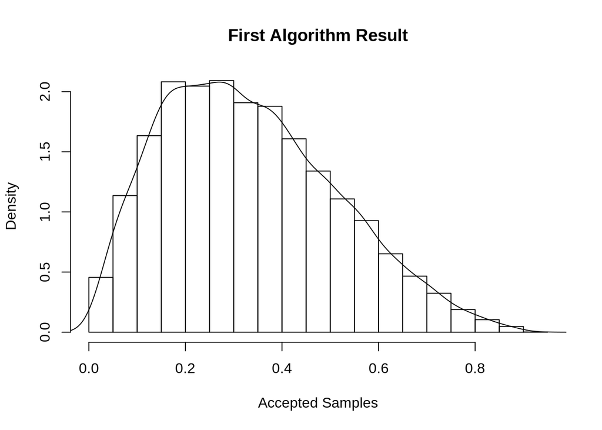

```r
hist(method1$z, freq = FALSE, breaks = 30, main = "First Algorithm Result", xlab = "Accepted Samples")
lines(density(method1$z))
```

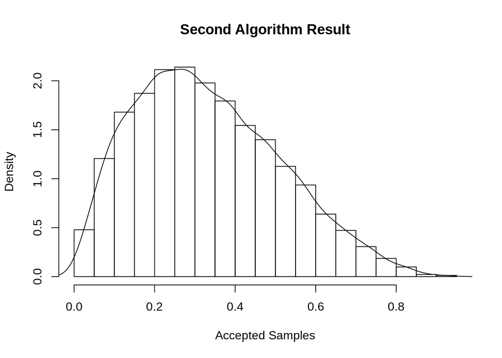

```r
hist(method2$z, freq = FALSE, breaks = 30, main = "Second Algorithm Result", xlab = "Accepted Samples")
lines(density(method2$z))
```

- **(e)** Summarizes your findings. I think both algorithms simulates the density well, though they may differ in acceptance rate.

## Solution 5

**Estimation of $\pi$.** $\pi$ is an irrational number between 3 and 4. In `R`, you can get an approximate value of `pi` directly when you enter `pi`. We will now estimate this value ourselves with simulation and compare it with the already available approximation.

- **(a)** Simulate 10000 pairs of random variables $(X_1, X_2)$, both from $Unif(-1,1)$. *Hint: Use the function `runif`. You can generate $X_1$ and $X_2$ separately.*
- **(b)** Find the number of times that $(X_1^2 + X_2^2) \leq 1$ for your sample. Call this number `n`.
- **(c)** Estimate $\pi$ by the number $4n/10000$. Check how close it is to the value given by `pi` in `R`.
- **(d)** Repeat this process 100 times to get a vector of estimates $\tilde{\pi}$.
- **(e)** Estimate the error in our approximation by calculating standard deviation of the vector $\tilde{\pi}$ divided by 10.
- **(a)**

```r
X1=runif(10000,-1,1)
X2=runif(10000,-1,1)
pairs <- data.frame(X1, X2)
```

- **(b)**

```r
n <- dim(subset(pairs, (X1^2+X2^2) <= 1))[1]
n
```

```
## [1] 7937
```

- **(c)**

```r
estimate=4*n/10000
estimate
```

```
## [1] 3.175
```

```r
abs(pi - estimate)
```

```
## [1] 0.03321
```

- **(d)**

```r
estimates <- rep(0, 100)
for (i in 1 : 100) {
  X1 <- runif(10000, -1, 1)
  X2 <- runif(10000, -1, 1)
  pairs <- data.frame(X1, X2)
  n <- dim(subset(pairs, (X1^2+X2^2) <= 1))[1]
  estimates[i] <- 4*n/10000
}
estimates
```

```
##   [1] 3.130 3.145 3.152 3.169 3.120 3.170 3.180 3.152 3.147 3.151 3.125 3.128
##  [13] 3.132 3.131 3.107 3.161 3.117 3.162 3.155 3.127 3.134 3.153 3.116 3.150
##  [25] 3.144 3.161 3.132 3.146 3.163 3.150 3.142 3.135 3.132 3.122 3.139 3.153
##  [37] 3.136 3.139 3.153 3.131 3.159 3.149 3.175 3.184 3.156 3.152 3.156 3.158
##  [49] 3.152 3.096 3.152 3.154 3.154 3.132 3.138 3.128 3.126 3.133 3.116 3.187
##  [61] 3.155 3.139 3.125 3.128 3.134 3.146 3.122 3.121 3.156 3.173 3.141 3.131
##  [73] 3.151 3.106 3.146 3.147 3.149 3.141 3.128 3.136 3.152 3.159 3.092 3.137
##  [85] 3.097 3.171 3.142 3.153 3.131 3.122 3.138 3.128 3.128 3.151 3.147 3.130
##  [97] 3.146 3.141 3.157 3.103
```

- **(e)**

```r
error = sd(estimates) / 10
error
```

```
## [1] 0.001845
```

## Solution 6

Suppose we want to generate random samples from a distribution with the following probability density function
$$f(x) = \begin{cases}
x, &0\leq x \leq 1,\\
2-x, &1<x \leq 2.
\end{cases}$$
Derive the probability inverse transformation $F^{-1}(U)$ and use the inverse transform method to simulate 1000 random samples from this distribution. Graph the density histogram of the sample.

$$F^{-1}(u) = \begin{cases}
\sqrt{2u}, & 0 \leq u \leq \frac{1}{2} \\
2 - \sqrt{2 - 2u}, & \frac{1}{2} < u \leq 1
\end{cases}$$

```r
inverse_F = function(y){
    return(ifelse(y <= 1/2, sqrt(2 * y), 2 - sqrt(2 - 2*y)))
}

us = runif(1000)
samples = sapply(us, inverse_F)
```

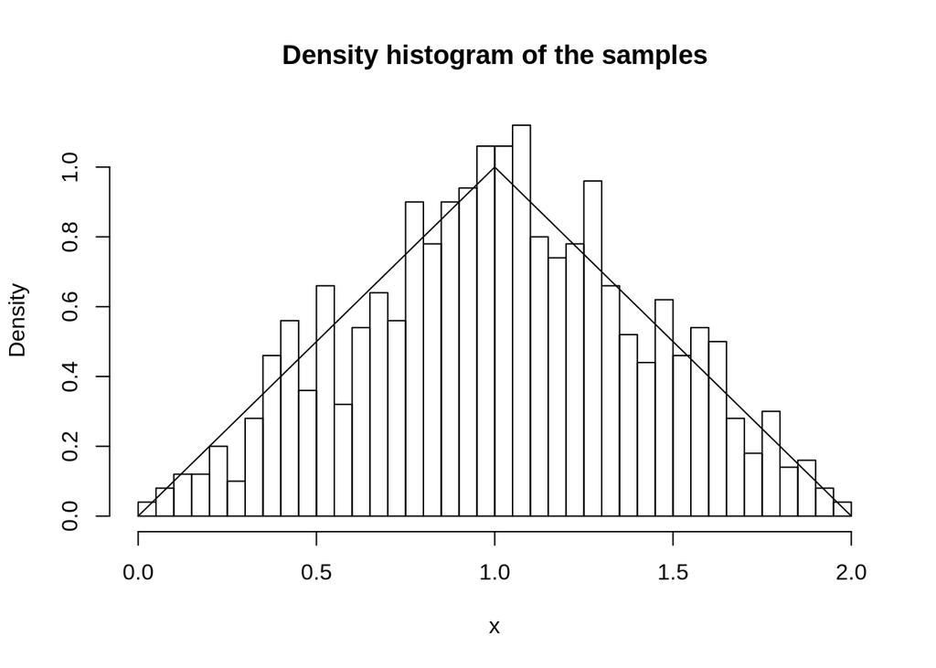

```r
hist(samples, freq = FALSE, breaks = 30, main = 'Density histogram of the samples', xlab = "x")
y <- seq(0, 2, by = 0.01)
lines(y, sapply(y, function(x) ifelse(x <= 1, x, 2-x)))
```

## Solution 7-10

Do the following exercises from the book: 3.2, 3.3, 3.7, 3.9

## Solution 7 (3.2)

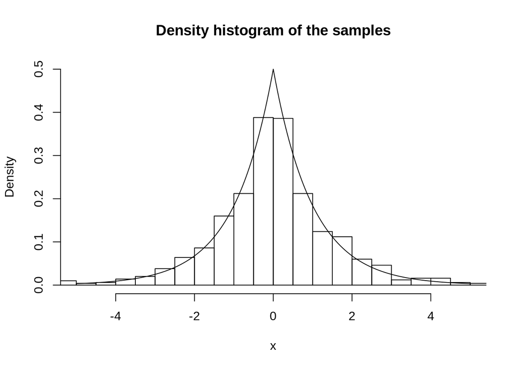

```r
u <- runif(1000)
f <- log(2 * u) * (u <= 0.5) - log(2 * (1 - u)) * (u > 0.5)

hist(f, probability = T, xlim=c(-5,5), ylim=c(0,0.5), breaks = 40, main="Density histogram of the samples", xlab = "x")
y <- seq(-5, 5, 0.01)
lines(y, 0.5 * exp(-abs(y)))
```

## Solution 8 (3.3)

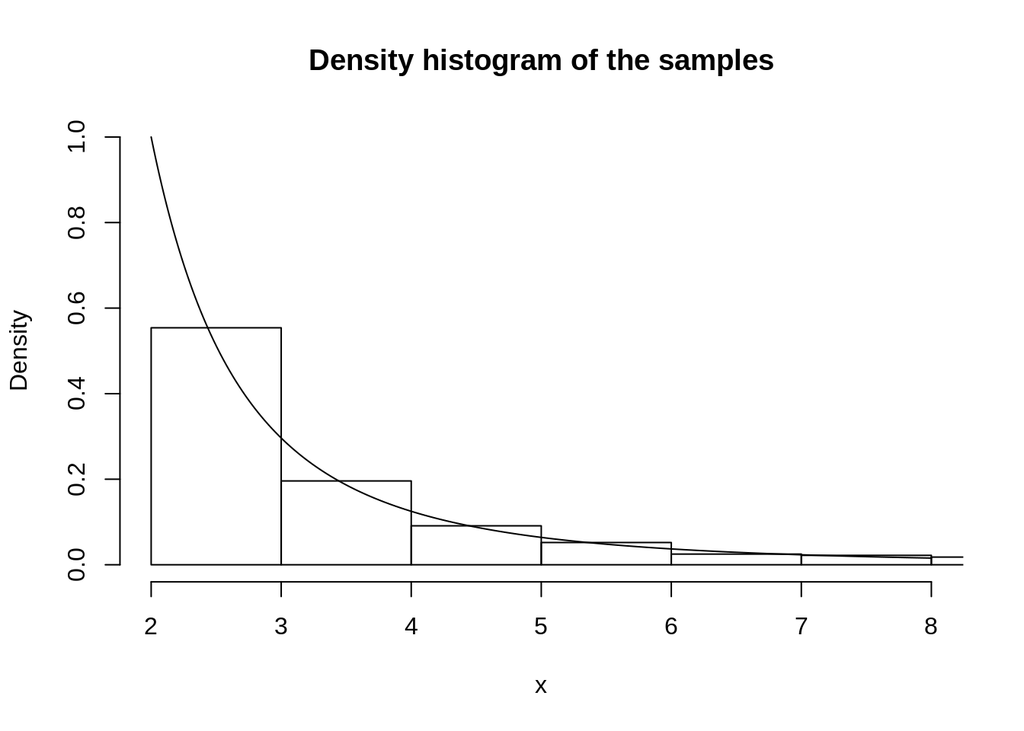

```r
u <- runif(1000)
f <- 2/sqrt(1-u)
hist(f, probability = T, breaks=200, xlim=c(2,8), ylim=c(0,1), main="Density histogram of the samples", xlab = "x")
y <- seq(2, 8, 0.01)
lines(y, 8 / (y^3))
```

## Solution 9 (3.7)

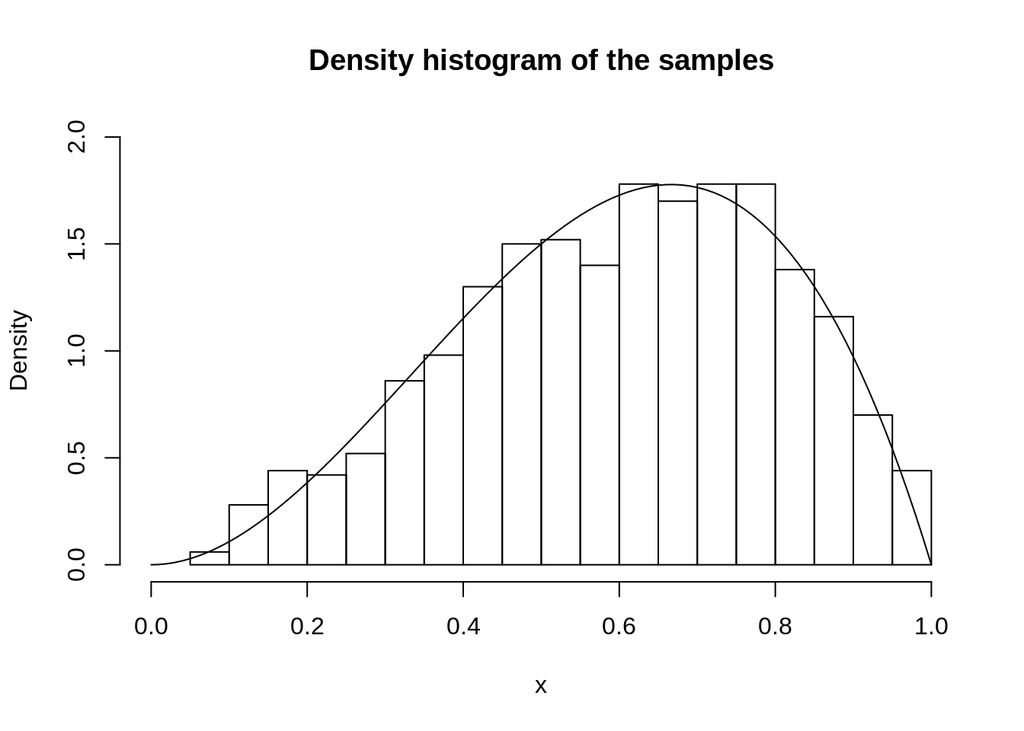

```r
accept <- 0
num <- 0
f <- rep(0, 100)
while (accept < 1000){
  u <- runif(1)
  num <- num + 1
  x <- sqrt(runif(1))
  if (x * (1-x) > u) {
    accept <- accept + 1
    f[accept] <- x
  }
}
hist(f, probability = T, main="Density histogram of the samples", xlab = "x", xlim=c(0,1), ylim=c(0,2), breaks = 30)
y <- seq(0,1,0.01)
lines(y, 12*(y^2)*(1-y))
```

## Solution 10 (3.9)

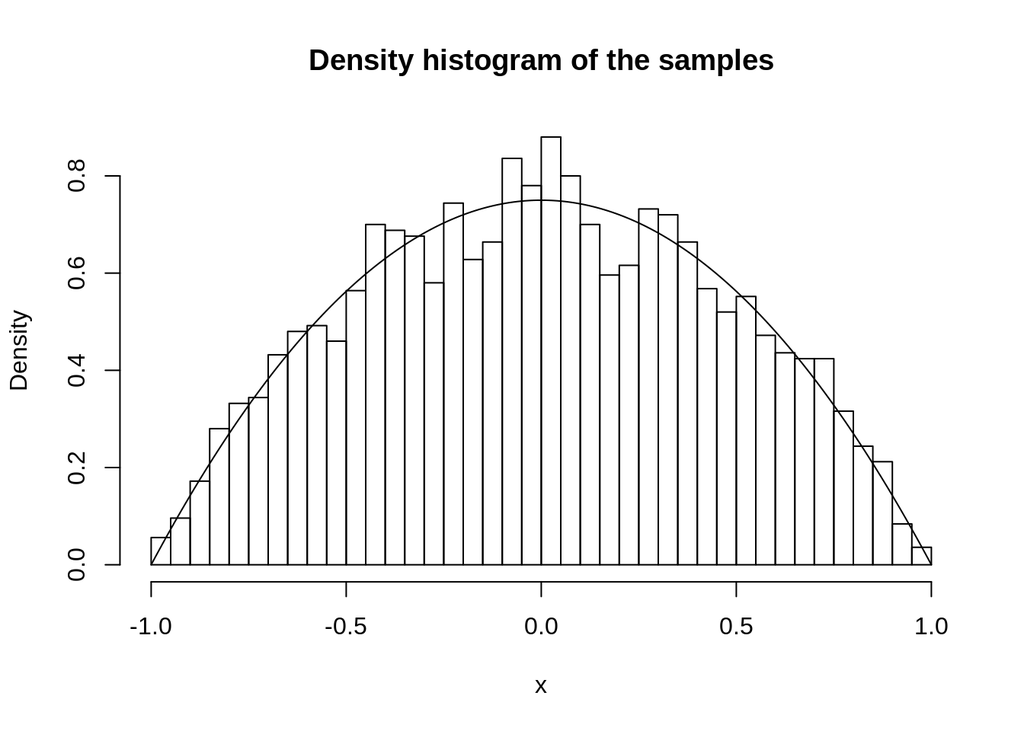

```r
u1 = runif(5000, -1, 1)
u2 = runif(5000, -1, 1)
u3 = runif(5000, -1, 1)
data = ifelse(abs(u3) >= abs(u2) & abs(u3) >= abs(u1), u2, u3)
hist(data, freq = F, main="Density histogram of the samples", xlab = "x", breaks = seq(-1, 1, by = 0.05))
y = seq(-1, 1, by = 0.01)
lines(y, 3/4 * (1 - y^2))
```